# Differential expression analysis for scRNA-seq data

Data Lab for ALSF

2023

## Objectives

This notebook will demonstrate how to:

- Use pseudo-bulking to prepare scRNA-seq libraries for differential expression
- Perform differential expression with the `DESeq2` package
- Use `ggplot2` and `EnhancedVolcano` to visualize gene expression changes across cell types and samples

Just like bulk RNA-seq, it is likely that one of the goals when performing scRNA-seq will be to compare the gene expression of multiple samples to each other. Unlike bulk RNA-seq analysis, scRNA-seq analysis allows us to identify and annotate cell types or subpopulations of cells present in each of our samples. This means that we can account for differences in cell type composition across samples and specifically focus on cell types or populations of interest when performing differential expression (DE) analysis. In this notebook, we will work with multiple samples to identify differentially expressed genes across cell types of interest using the [`DESeq2`](https://bioconductor.org/packages/release/bioc/html/DESeq2.html) package.

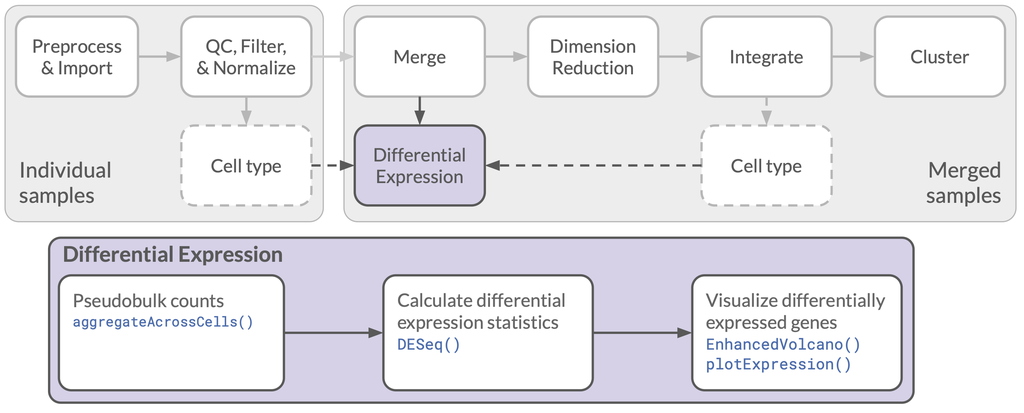

Single-cell roadmap: Differential expression

## Set up

```r
# set seed for reproducibility
set.seed(2022)

# load libraries
library(ggplot2) # plotting functions
library(SingleCellExperiment)

# package used for differential expression analysis
library(DESeq2)
```

### Directories and files

We will start by reading in a `SingleCellExperiment` (SCE) object that contains both the uncorrected (merged but not integrated) and corrected (integrated) gene expression data for all 10 samples.

We also have provided a metadata file, `data/rms/annotations/rms_sample_metadata.tsv`, that contains information from each sample, such as diagnosis, sex, age, etc. Each row in this file corresponds to a sample found in the integrated SCE object.

To begin, let’s set up our directories and files:

```r
# set up file paths
# data directory for RMS data
data_dir <- file.path("data", "rms")

# integrated file containing samples to use for DE analysis
integrated_sce_file <- file.path(
  data_dir,
  "integrated",
  "rms_all_sce.rds"
)

# sample metadata to set up DE analysis
sample_metadata_file <- file.path(
  data_dir,
  "annotations",
  "rms_sample_metadata.tsv"
)

# directory to store output
deseq_dir <- file.path("analysis", "rms", "deseq")
fs::dir_create(deseq_dir)

# results file to output from DE analysis
deseq_output_file <- file.path(
  deseq_dir,
  "rms_myoblast_deseq_results.tsv"
)

# output integrated sce object
output_sce_file <- file.path(
  data_dir,
  "integrated",
  "rms_subset_sce.rds"
)
```

We can go ahead and read in the SCE object and the metadata file.

```r
# read in the SCE object that has already been integrated
integrated_sce <- readRDS(integrated_sce_file)

# read in sample metadata file
sample_metadata <- readr::read_tsv(sample_metadata_file)
```

## Dataset exploration

Before we dive into differential expression, let’s explore our integrated SCE object and the dataset a little more.

We’ll start by looking at what’s inside the object. Here we should have both the original (uncorrected) data and the integrated (corrected) data for both the gene expression and the reduced dimensionality results. How are those stored in our object?

```r
# print out entire object
integrated_sce
```

```
class: SingleCellExperiment
dim: 60319 39332
metadata(141): salmon_version reference_index ... miQC_model combined_hvg
assays(3): counts logcounts fastmnn_corrected
rownames(60319): ENSG00000000003 ENSG00000000005 ... ENSG00000288724 ENSG00000288725
rowData names(21): gene_symbol SCPCL000478-mean ... SCPCL000498-mean SCPCL000498-detected
colnames(39332): SCPCL000478-CCTTTGGCACTACCCT SCPCL000478-GCAACCGGTCTTAGTG ...
  SCPCL000498-CGTCAAATCGAGAATA SCPCL000498-GGAACCCCACGACAAG
colData names(13): sum detected ... celltype_broad sample
reducedDimNames(4): PCA UMAP fastmnn_PCA fastmnn_UMAP
mainExpName: NULL
altExpNames(0):
```

```r
# look at the assay names in our object
names(integrated_sce@assays)
```

```
[1] "counts"            "logcounts"         "fastmnn_corrected"
```

When we look at the assay names we should see that there are 3 matrices, `counts`, `logcounts`, and `fastmnn_corrected`. The `counts` and `logcounts` assays correspond to the uncorrected gene expression data that has been merged but NOT integrated. The `fastmnn_corrected` data contains the corrected gene expression data obtained from integration. For this exercise we will not be using the `fastmnn_corrected` data (more on why not once we get to setting up the differential expression), but we need to be aware that it is present and be able to distinguish it from our uncorrected data.

```r
# look at the names of the dimension reductions
reducedDimNames(integrated_sce)
```

```
[1] "PCA"          "UMAP"         "fastmnn_PCA"  "fastmnn_UMAP"
```

In the `reducedDim` slots you should see `PCA` and `UMAP`, which were both calculated from the combined data *before* integration. You should also see `fastmnn_PCA` and `fastmnn_UMAP` reduced dimensions, which correspond to the integrated results.

### Cell type annotations

Just like in the integration notebook, this dataset also contains the cell type annotations found in the `celltype_fine` and `celltype_broad` columns of the `colData`. These cell types were originally assigned in [Patel *et al.* (2022)](https://doi.org/10.1016/j.devcel.2022.04.003). We will use these cell type assignments to set up the DE analysis below, but they are not required for DE analysis itself. It’s important to note that DE analysis can be applied to any subpopulation of interest that is shared across samples besides just cell types.

Because we are going to be doing DE analysis between ARMS and ERMS samples, let’s start by labeling cells in the integrated dataset based on their RMS subtype. To do this we will need to be sure that the subtype is present in the `colData` of the integrated SCE object. If it’s not there, we need to add it in.

```r
# look at the head of the coldata
head(colData(integrated_sce))
```

```
DataFrame with 6 rows and 13 columns
                                   sum  detected subsets_mito_sum subsets_mito_detected subsets_mito_percent
                             <numeric> <integer>        <numeric>             <integer>            <numeric>
SCPCL000478-CCTTTGGCACTACCCT     32646      7164              194                    14            0.5942535
SCPCL000478-GCAACCGGTCTTAGTG     29168      7462              283                    13            0.9702414
SCPCL000478-TCACTATCAAATCCCA     29572      5415              569                    15            1.9241174
SCPCL000478-TATATCCCACTCTCGT     31423      4734              445                    14            1.4161601
SCPCL000478-GCACTAACATTACGGT     43455      8669              285                    12            0.6558509
SCPCL000478-ACCCAAAAGTTGGGAC     43123      9099               18                     6            0.0417411
                                 total prob_compromised miQC_pass sizeFactor          barcode
                             <numeric>        <numeric> <logical>  <numeric>      <character>
SCPCL000478-CCTTTGGCACTACCCT     32646        0.0618259      TRUE   10.91988 CCTTTGGCACTACCCT
SCPCL000478-GCAACCGGTCTTAGTG     29168        0.0924980      TRUE    9.76666 GCAACCGGTCTTAGTG
SCPCL000478-TCACTATCAAATCCCA     29572        0.1389403      TRUE    9.11819 TCACTATCAAATCCCA
SCPCL000478-TATATCCCACTCTCGT     31423        0.0625259      TRUE    8.40648 TATATCCCACTCTCGT
SCPCL000478-GCACTAACATTACGGT     43455        0.0968148      TRUE   14.96269 GCACTAACATTACGGT
SCPCL000478-ACCCAAAAGTTGGGAC     43123        0.0645065      TRUE   14.70095 ACCCAAAAGTTGGGAC
                                    celltype_fine       celltype_broad      sample
                                      <character>          <character> <character>
SCPCL000478-CCTTTGGCACTACCCT                   NA                   NA SCPCL000478
SCPCL000478-GCAACCGGTCTTAGTG                   NA                   NA SCPCL000478
SCPCL000478-TCACTATCAAATCCCA Vascular Endothelium Vascular Endothelium SCPCL000478
SCPCL000478-TATATCCCACTCTCGT Vascular Endothelium Vascular Endothelium SCPCL000478
SCPCL000478-GCACTAACATTACGGT                   NA                   NA SCPCL000478
SCPCL000478-ACCCAAAAGTTGGGAC                   NA                   NA SCPCL000478
```

Uh oh, it looks like the RMS subtype is not found in the SCE object. Fortunately we also have the sample metadata table that we read in earlier, which contains information about each of the samples present in the dataset.

| project_id | submitter | library_id | sample_id | diagnosis | technology | seq_unit | subdiagnosis | tissue_location | disease_timing |
| --- | --- | --- | --- | --- | --- | --- | --- | --- | --- |
| SCPCP000005 | dyer_chen | SCPCL000495 | SCPCS000250 | Rhabdomyosarcoma | 10Xv3 | nucleus | Embryonal rhabdomyosarcoma | Lung | Recurrence |
| SCPCP000005 | dyer_chen | SCPCL000478 | SCPCS000252 | Rhabdomyosarcoma | 10Xv3 | nucleus | Embryonal rhabdomyosarcoma | Infratemporal fossa | Recurrence |
| SCPCP000005 | dyer_chen | SCPCL000479 | SCPCS000253 | Rhabdomyosarcoma | 10Xv3 | nucleus | Embryonal rhabdomyosarcoma | Prostate | Recurrence |
| SCPCP000005 | dyer_chen | SCPCL000480 | SCPCS000254 | Rhabdomyosarcoma | 10Xv3 | nucleus | Embryonal rhabdomyosarcoma | Prostate/bladder | Recurrence |
| SCPCP000005 | dyer_chen | SCPCL000481 | SCPCS000255 | Rhabdomyosarcoma | 10Xv3 | nucleus | Embryonal rhabdomyosarcoma | Pelvis | Recurrence |
| SCPCP000005 | dyer_chen | SCPCL000498 | SCPCS000251 | Rhabdomyosarcoma | 10Xv3 | nucleus | Alveolar rhabdomyosarcoma | Abdominal wall | Initial diagnosis |

Looking at this sample table, we see a column named `subdiagnosis` which accounts for the RMS subtype, ARMS or ERMS. We also see other columns that contain information about each specific sample.

We can incorporate the information in this sample metadata table into the `colData` of the integrated SCE object. This will allow us to match each of the samples in the SCE object with the RMS subtype and also allow us to use any of the columns in the sample metadata for plotting.

```r
# add sample metadata to colData from the integrated SCE object
coldata_df <- colData(integrated_sce) |>
  # convert from DataFrame to data.frame
  as.data.frame() |>
  # merge with sample metadata
  dplyr::left_join(sample_metadata, by = c("sample" = "library_id")) |>
  # create new columns
  # cell_id is a combination of barcode and sample
  dplyr::mutate(
    cell_id = glue::glue("{sample}-{barcode}"),
    # simplify subdiagnosis
    diagnosis_group = forcats::fct_recode(
      subdiagnosis,
      "ARMS" = "Alveolar rhabdomyosarcoma",
      "ERMS" = "Embryonal rhabdomyosarcoma"
    )
  )

# add modified data frame back to SCE as DataFrame
colData(integrated_sce) <- DataFrame(
  coldata_df,
  row.names = coldata_df$cell_id
)
```

Now when we look at the `colData` of the SCE object we should see new columns, including the `diagnosis_group` column which indicates if each cell comes from an ERMS or ARMS sample.

```r
# take a look at the new modified colData
head(colData(integrated_sce))
```

```
DataFrame with 6 rows and 24 columns
                                   sum  detected subsets_mito_sum subsets_mito_detected subsets_mito_percent
                             <numeric> <integer>        <numeric>             <integer>            <numeric>
SCPCL000478-CCTTTGGCACTACCCT     32646      7164              194                    14            0.5942535
SCPCL000478-GCAACCGGTCTTAGTG     29168      7462              283                    13            0.9702414
SCPCL000478-TCACTATCAAATCCCA     29572      5415              569                    15            1.9241174
SCPCL000478-TATATCCCACTCTCGT     31423      4734              445                    14            1.4161601
SCPCL000478-GCACTAACATTACGGT     43455      8669              285                    12            0.6558509
SCPCL000478-ACCCAAAAGTTGGGAC     43123      9099               18                     6            0.0417411
                                 total prob_compromised miQC_pass sizeFactor          barcode
                             <numeric>        <numeric> <logical>  <numeric>      <character>
SCPCL000478-CCTTTGGCACTACCCT     32646        0.0618259      TRUE   10.91988 CCTTTGGCACTACCCT
SCPCL000478-GCAACCGGTCTTAGTG     29168        0.0924980      TRUE    9.76666 GCAACCGGTCTTAGTG
SCPCL000478-TCACTATCAAATCCCA     29572        0.1389403      TRUE    9.11819 TCACTATCAAATCCCA
SCPCL000478-TATATCCCACTCTCGT     31423        0.0625259      TRUE    8.40648 TATATCCCACTCTCGT
SCPCL000478-GCACTAACATTACGGT     43455        0.0968148      TRUE   14.96269 GCACTAACATTACGGT
SCPCL000478-ACCCAAAAGTTGGGAC     43123        0.0645065      TRUE   14.70095 ACCCAAAAGTTGGGAC
                                    celltype_fine       celltype_broad      sample  project_id   submitter
                                      <character>          <character> <character> <character> <character>
SCPCL000478-CCTTTGGCACTACCCT                   NA                   NA SCPCL000478 SCPCP000005   dyer_chen
SCPCL000478-GCAACCGGTCTTAGTG                   NA                   NA SCPCL000478 SCPCP000005   dyer_chen
SCPCL000478-TCACTATCAAATCCCA Vascular Endothelium Vascular Endothelium SCPCL000478 SCPCP000005   dyer_chen
SCPCL000478-TATATCCCACTCTCGT Vascular Endothelium Vascular Endothelium SCPCL000478 SCPCP000005   dyer_chen
SCPCL000478-GCACTAACATTACGGT                   NA                   NA SCPCL000478 SCPCP000005   dyer_chen
SCPCL000478-ACCCAAAAGTTGGGAC                   NA                   NA SCPCL000478 SCPCP000005   dyer_chen
                               sample_id        diagnosis  technology    seq_unit           subdiagnosis
                             <character>      <character> <character> <character>            <character>
SCPCL000478-CCTTTGGCACTACCCT SCPCS000252 Rhabdomyosarcoma       10Xv3     nucleus Embryonal rhabdomyos..
SCPCL000478-GCAACCGGTCTTAGTG SCPCS000252 Rhabdomyosarcoma       10Xv3     nucleus Embryonal rhabdomyos..
SCPCL000478-TCACTATCAAATCCCA SCPCS000252 Rhabdomyosarcoma       10Xv3     nucleus Embryonal rhabdomyos..
SCPCL000478-TATATCCCACTCTCGT SCPCS000252 Rhabdomyosarcoma       10Xv3     nucleus Embryonal rhabdomyos..
SCPCL000478-GCACTAACATTACGGT SCPCS000252 Rhabdomyosarcoma       10Xv3     nucleus Embryonal rhabdomyos..
SCPCL000478-ACCCAAAAGTTGGGAC SCPCS000252 Rhabdomyosarcoma       10Xv3     nucleus Embryonal rhabdomyos..
                                 tissue_location disease_timing                cell_id diagnosis_group
                                     <character>    <character>                 <glue>        <factor>
SCPCL000478-CCTTTGGCACTACCCT Infratemporal fossa     Recurrence SCPCL000478-CCTTTGGC..            ERMS
SCPCL000478-GCAACCGGTCTTAGTG Infratemporal fossa     Recurrence SCPCL000478-GCAACCGG..            ERMS
SCPCL000478-TCACTATCAAATCCCA Infratemporal fossa     Recurrence SCPCL000478-TCACTATC..            ERMS
SCPCL000478-TATATCCCACTCTCGT Infratemporal fossa     Recurrence SCPCL000478-TATATCCC..            ERMS
SCPCL000478-GCACTAACATTACGGT Infratemporal fossa     Recurrence SCPCL000478-GCACTAAC..            ERMS
SCPCL000478-ACCCAAAAGTTGGGAC Infratemporal fossa     Recurrence SCPCL000478-ACCCAAAA..            ERMS
```

### Plotting with annotations

We can now use that column to label any UMAP plots (or other plot types) that we make. In the chunk below we will start by taking a look at our integration results and color our cells by RMS subtype.

**Reminder: You should always use the batch-corrected dimensionality reduction results for visualizing datasets containing multiple libraries or samples.**

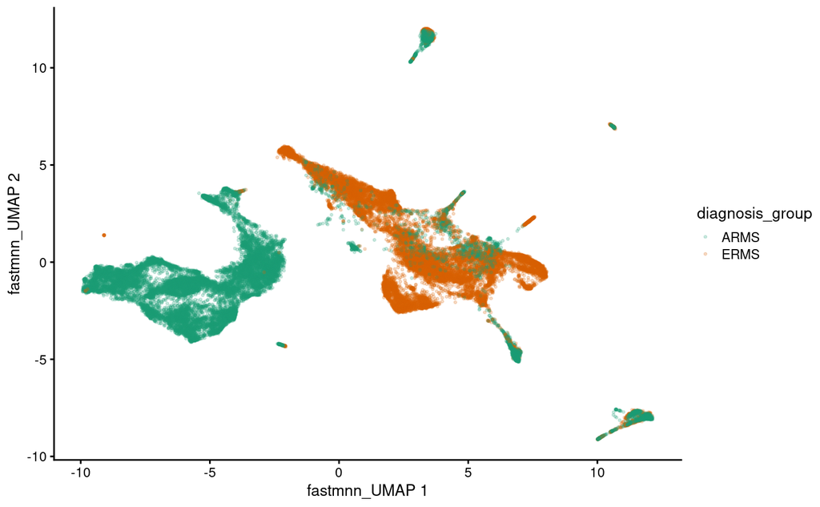

```r
# UMAP of all samples, separating by diagnosis group
scater::plotUMAP(integrated_sce,
                 dimred = "fastmnn_UMAP",
                 color_by = "diagnosis_group",
                 point_size = 0.5,
                 point_alpha = 0.2
) +
  scale_color_brewer(palette = "Dark2", name = 'diagnosis_group')
```

```r
  ggtitle("UMAP by diagnosis group")
```

```
$title
[1] "UMAP by diagnosis group"

attr(,"class")
[1] "labels"
```

Interestingly, it looks like samples from the ARMS and ERMS subtypes tend to group with samples of the same subtype rather than all together.

In the integration notebook we also looked at the distribution of cell types after integration. In that notebook, we discussed that cells of the same cell type are expected to integrate with other cells of the same type. Is that the case with this dataset?

A word of caution when evaluating the cell type results for this dataset: The cell types for this dataset were assigned in a two stage process as described in [Patel *et al.* (2022)](https://doi.org/10.1016/j.devcel.2022.04.003). The first stage assigned cells as tumor or non-tumor. The next stage further classified tumor cells into one of three types of tumor cells: myoblast, myocyte, or mesoderm. Some samples could not be further classified, so all of their tumor cells are denoted `Tumor`. The samples which could be further classified have a mix of `Tumor_Mesoderm`, `Tumor_Myoblast`, and `Tumor_Myocyte`.

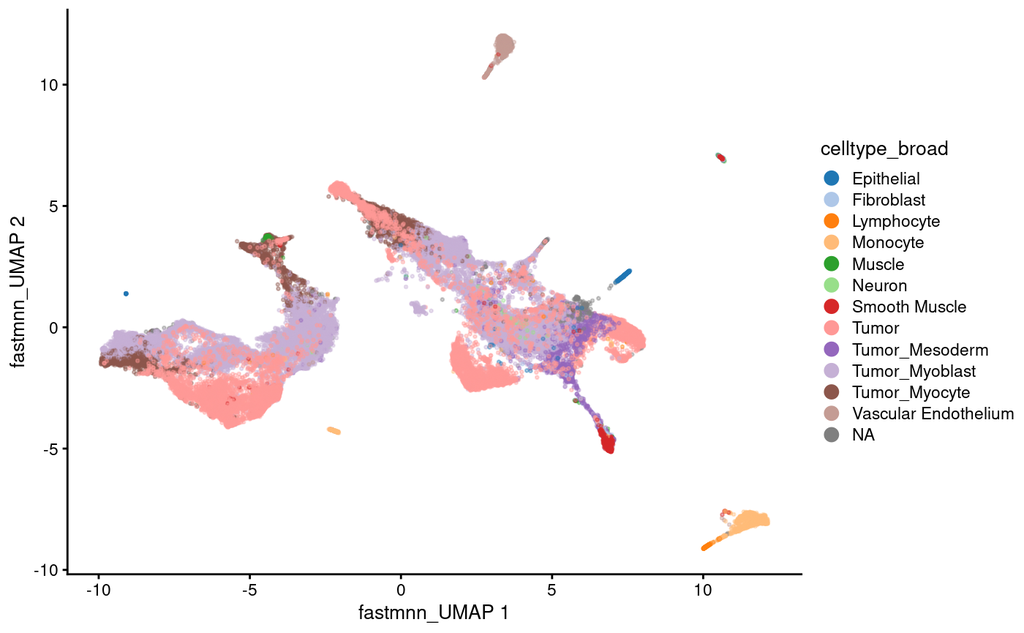

```r
# UMAP of all samples labeled by cell type
scater::plotReducedDim(
  integrated_sce,
  dimred = "fastmnn_UMAP",
  # color each point by cell type
  color_by = "celltype_broad",
  point_size = 0.5,
  point_alpha = 0.4
) +
  # Modify the legend key with larger, easier to see points
  guides(color = guide_legend(override.aes = list(size = 3, alpha = 1)))
```

Unlike with the previous datasets we have seen where all cells of the same cell type always grouped together, this dataset shows some slightly different patterns and not all cells of the same cell type cluster together. One reason is that tumor data can be heterogeneous and every tumor is unique. Depending on the tumor type we may not expect every sample to integrate perfectly and more heterogeneous tumor types will be more difficult to integrate together. In this particular case we are looking at two subtypes of RMS that have distinct mutation burdens and differentiation states, so it’s likely that those differences contribute to how well they integrate.

To explore whether cells are grouping together both by cell type and by RMS subtype, we can create a plot that incorporates both pieces of metadata. We will take advantage of the `facet_grid()` function from `ggplot2` to look at two variables in the `colData` at once - the cell type and the subdiagnosis. In the below plot we will color our cells by cell type while also using `facet_grid()` so that cells from different subdiagnoses will be in their own plot panel.

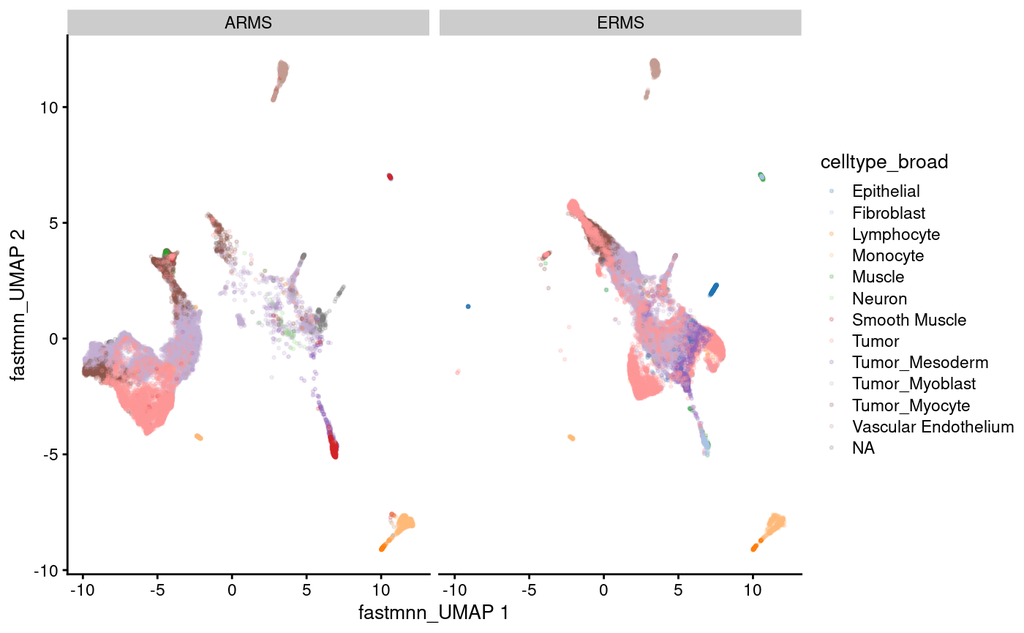

```r
# UMAP of all samples
# separating by diagnosis group and labeling cell type
scater::plotReducedDim(
  integrated_sce,
  dimred = "fastmnn_UMAP",
  # color each point by cell type
  color_by = "celltype_broad",
  point_size = 0.5,
  point_alpha = 0.2,
  # tell scater to use diagnosis_group for plotting
  other_fields = "diagnosis_group",
) +
  # include each diagnosis group as its own column
  facet_grid(cols = vars(diagnosis_group))
```

As expected, we see that cell types are separated, most likely due to different RMS subtypes.

We can also use a stacked barplot to look at the distribution of cell types across each sample, which will require a bit of wrangling first.

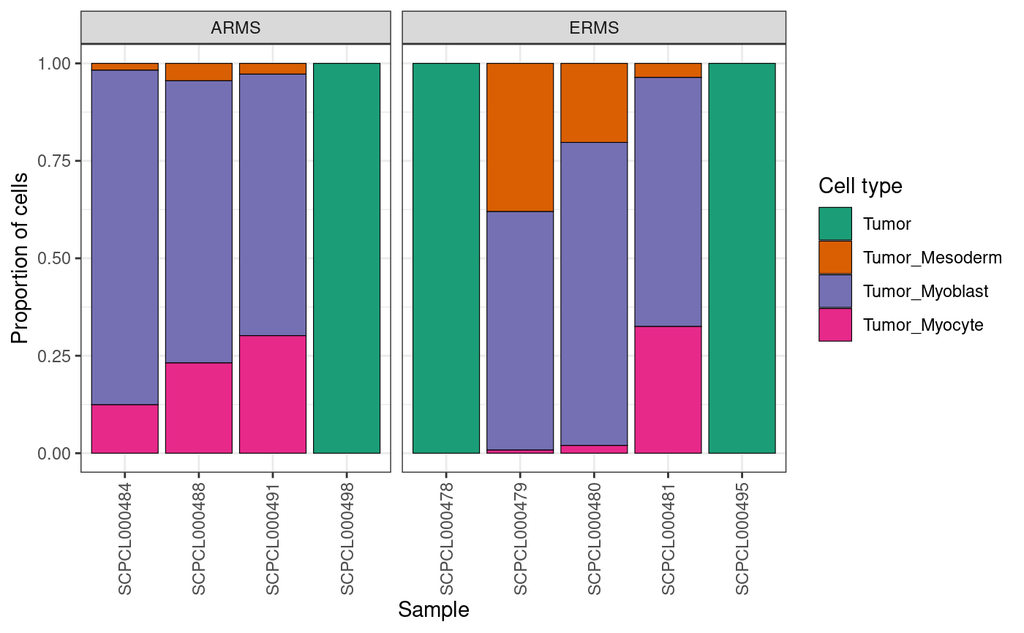

```r
# filter coldata to only include tumor cells
tumor_cells_df <- coldata_df |>
  # find rows where the cell type name contains the string "Tumor"
  dplyr::filter(stringr::str_detect(celltype_broad, "Tumor"))

# create a stacked barplot
ggplot(tumor_cells_df, aes(x = sample, fill = celltype_broad)) +
  geom_bar(position = "fill", color = "black", size = 0.2) +
  labs(
    x = "Sample",
    y = "Proportion of cells",
    fill = "Cell type"
  ) +
  scale_fill_brewer(palette = "Dark2") +
  theme_bw() +
  theme(axis.text.x = element_text(angle = 90, vjust = 0.5)) +
  # facet by diagnosis group
  facet_grid(
    cols = vars(diagnosis_group),
    # only show non-NA values on x-axis
    scales = "free_x",
    space = "free_x"
  )
```

Similar to the UMAP, this plot shows that ARMS and ERMS share a lot of the same cell types.

We also see that only 6 of these libraries have tumor cells that have been further classified into mesoderm, myoblast, and myocyte. 3 libraries contain cells that are only classified as tumor or non-tumor, and tumor cells are not further classified, and the remaining library is not even present in our plot because it was not assigned any cell types (all are `NA`). We will continue our analysis only using the 6 libraries with fully classified cell types, removing the other 4 before we proceed with differential expression.

### Filtering samples

The reason we want to pare down our list of samples to consider is that we want to ensure that the cell types (or subpopulations) that we are interested in are present in all samples included in our DE analysis. We want to remove any samples that do not contain our cell population(s) of interest as they have no counts to contribute to the DE analysis.

```r
# define samples to keep
library_ids <- c(
  "SCPCL000479",
  "SCPCL000480",
  "SCPCL000481",
  "SCPCL000484",
  "SCPCL000488",
  "SCPCL000491"
)

# subset sce to only contain samples of interest
samples_to_keep <- integrated_sce$sample %in% library_ids
rms_sce <- integrated_sce[, samples_to_keep]

# print out our new SCE
rms_sce
```

```
class: SingleCellExperiment
dim: 60319 26033
metadata(141): salmon_version reference_index ... miQC_model combined_hvg
assays(3): counts logcounts fastmnn_corrected
rownames(60319): ENSG00000000003 ENSG00000000005 ... ENSG00000288724 ENSG00000288725
rowData names(21): gene_symbol SCPCL000478-mean ... SCPCL000498-mean SCPCL000498-detected
colnames(26033): SCPCL000479-GGGACCTCAAGCGGAT SCPCL000479-CACAGATAGTGAGTGC ...
  SCPCL000491-TCGCACTAGGAACGTC SCPCL000491-TTGCATTTCAACGCTA
colData names(24): sum detected ... cell_id diagnosis_group
reducedDimNames(4): PCA UMAP fastmnn_PCA fastmnn_UMAP
mainExpName: NULL
altExpNames(0):
```

Before we move on, we’ll remove the original integrated object from our environment to save some memory.

```r
rm(integrated_sce)
```

We will also save our new object in case we want to use it for other analysis later on.

```r
# write RDS file with compression
readr::write_rds(rms_sce, file = output_sce_file, compress = "gz")
```

We now have an updated SCE object that contains 6 samples that were obtained from a mix of ARMS and ERMS patients. We can then ask the question, do specific tumor cell types contain sets of differentially expressed genes between ARMS and ERMS samples?

We should make sure that we have enough biological replicates from each group to set up our experiment. It is imperative to consider good experimental design and ensure that we have enough biological replicates (at least 3 for each group) when performing differential gene expression analysis.

If we look back at our stacked barplot we see that we picked 3 ARMS and 3 ERMS samples. We can also see that the majority of cells are tumor cells, in particular the largest population of cells appears to be the `Tumor_Myoblast`. For this example we will focus on identifying DE genes in these `Tumor_Myoblast` cells, but the principles applied below can be applied to any cell types or subpopulations of interest.

## Differential expression analysis

Now we are ready to start preparing for our DE analysis, where we will compare the gene expression of tumor myoblast cells between ARMS and ERMS samples.

Throughout the notebook we have been working with an integrated dataset that contains corrected gene expression data (`fastmnn_corrected` assay) and a corrected UMAP. As a reminder, the uncorrected gene expression data, found in the `counts` and `logcounts` assays, correspond to data that has been merged (the first step we walked through prior to integration) into the same SCE but not yet integrated. We do not want to use corrected gene expression values for differential expression; `DESeq2` expects the original raw counts as input so we will be using data found in the `counts` assay of the `SingleCellExperiment` object.

It is advised to only use the corrected values for any analyses being performed at the cell level, e.g., dimensionality reduction. In contrast, it is not advised to use corrected values for any analyses that are gene-based, such as differential expression or marker gene detection, because within-batch and between-batch gene expression differences are no longer preserved. The reason for this is two-fold – many of the DE models will expect uncorrected counts because they will account for between-sample variation within the model, and we want to ensure we are preserving variation that is present so as not to artificially inflate differences between populations. See the [OSCA chapter on Using the corrected values](https://bioconductor.org/books/3.19/OSCA.multisample/using-corrected-values.html#using-corrected-values) for more insight.